# Weather data analysis

Yuting

7 June 2021

## 1. Parse json data

```r
library(rjson)
library(jsonlite)
library(dplyr)

data<-jsonlite::stream_in(file("./weather.json/weather.json"))
```

[output not shown]

[output cut: 367 more lines]

[output not shown]

```r
head(data)
```

```
##   city.id city.name city.findname city.country city.coord.lon
## 1   14256 Azadshahr     AZADSHAHR           IR       48.57073
## 2   56166     Jilib         JILIB           SO       42.78535
## 3   55671  Kismaayo      KISMAAYO           SO       42.54536
## 4   60019       Eyl           EYL           SO       49.81640
## 5   23814    Kahriz        KAHRIZ           IR       47.05530
## 6   53654 Mogadishu     MOGADISHU           SO       45.34375
##   city.coord.lat city.zoom       time main.temp main.pressure
## 1       34.79088        10 1554462304   287.070       1022.00
## 2        0.48829         9 1554462304   309.929       1008.39
## 3       -0.35817         6 1554462304   301.329       1009.87
## 4        7.98030         5 1554462304   302.229       1010.67
## 5       34.38380         7 1554462304   285.620       1021.00
## 6        2.03711         1 1554462304   305.150       1011.00
##   main.humidity main.temp_min main.temp_max wind.speed wind.deg all
## 1            71       284.150       289.150       4.10    340.0  90
## 2            36       309.929       309.929       5.72    104.0   0
## 3           100       301.329       301.329       6.12    103.5   0
## 4            80       302.229       302.229       5.02    111.5   0
## 5            66       285.150       286.150       2.10    150.0  75
## 6            59       305.150       305.150       5.10    100.0  75
##                             weather
## 1 804, Clouds, overcast clouds, 04d
## 2        800, Clear, clear sky, 01d
## 3        800, Clear, clear sky, 01d
## 4        800, Clear, clear sky, 01d
## 5   803, Clouds, broken clouds, 04d
## 6   803, Clouds, broken clouds, 04d
```

```r
city=data$city
time=as.POSIXct(data$time, origin = "1970-01-01") # convert unix timestamp to date
main=data$main
wind=data$wind
clouds=data$clouds
weather=bind_rows(data$weather)
```

The first step is to transform the data into a form that can be easily analysed. Notice that: 1.The time variable in the original dataset is unix timestamp, I changed it back to date time format to verify that these data are on taken at the same time (2019 April 5th 12.05pm-12.08pm); 2. The weather table was a list of 209,579 dataframes, hence I first combined them into one dataframe for easier analysis.

## 2. Combine variables into one data frame

```r
dat=cbind(city, time, main, wind, clouds)
# rename some variables
dat= dat %>%
 rename(
 cityname = name,
 clouds = all
 )
```

## 3. Data Visualisation

First, I plotted the correlation matrix between variables and then explore the relationship in details.

#### Correlation Matrix Plot

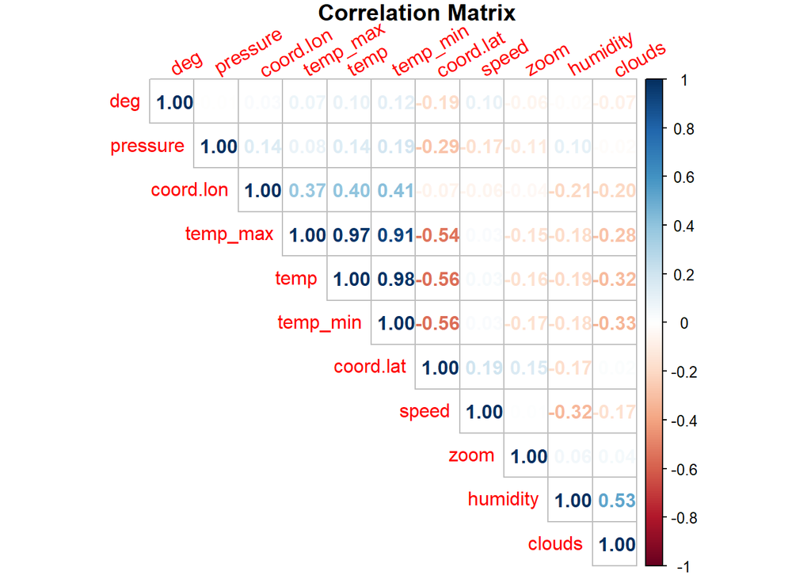

```r
library(corrplot)
correlations <- cor(dat[,c(5:6,8:15)], use="pairwise", method="spearman")
corrplot(correlations, tl.srt = 30,title='Correlation Matrix', mar=c(0,1,1,0), method="number", type="upper", order="hclust")
```

It can be seen that: 1. Temperature has moderate negative relationship with latitude, moderate positive relationship with longitude and slightly negative relationship with cloudliness. 2. Humidity has moderate positive relationship with cloudliness and slightly negative relationship with wind speed. Next, we look into the correlation in more details。

#### Temperature

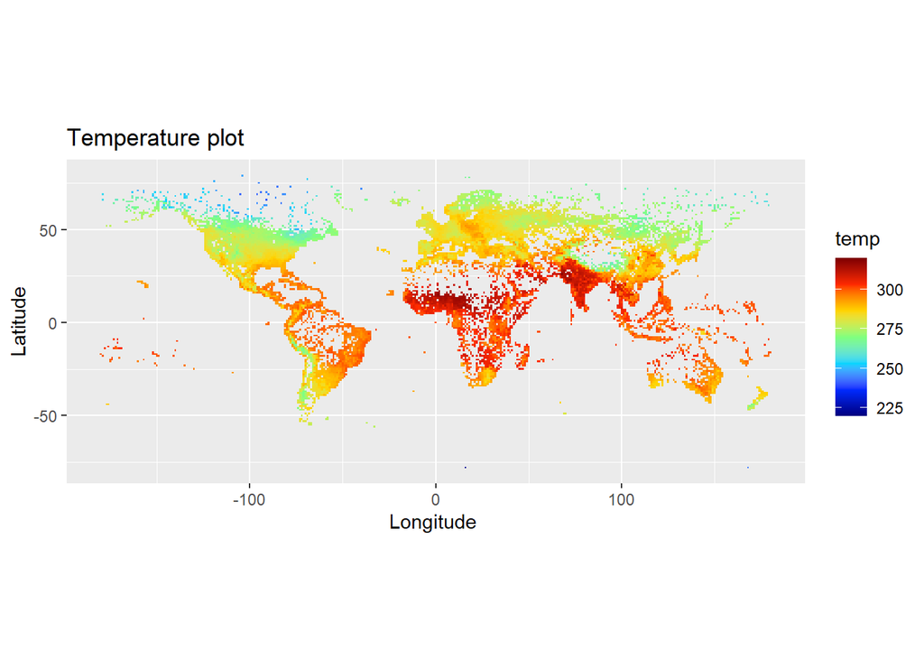

```r
library(ggplot2)
jet.colors <- colorRampPalette(c("#00007F", "blue", "#007FFF", "cyan", "#7FFF7F", "yellow", "#FF7F00", "red", "#7F0000"))
p=ggplot() +
 geom_tile(data = dat, aes(x=round(coord$lon), y=round(coord$lat), fill=temp)) + scale_fill_gradientn(colors = jet.colors(7), limits = c(220, 320)) +
 coord_quickmap()
p+labs(title="Temperature plot",  x ="Longitude ", y = "Latitude")
```

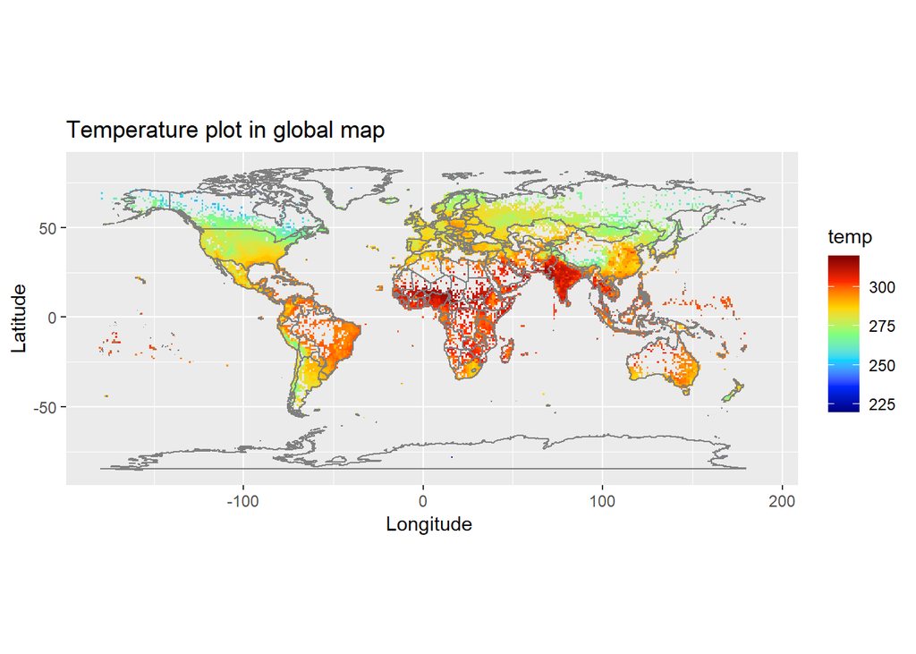

```r
# temperature map with continents added
library(maps)
p+ borders() +labs(title="Temperature plot in global map",
x ="Longitude ", y = "Latitude")
```

It can be seen that the temperature is higher for countries closer to equator. It peaks at around 0-100 longitude and 0-30 latitude.

#### Humidity

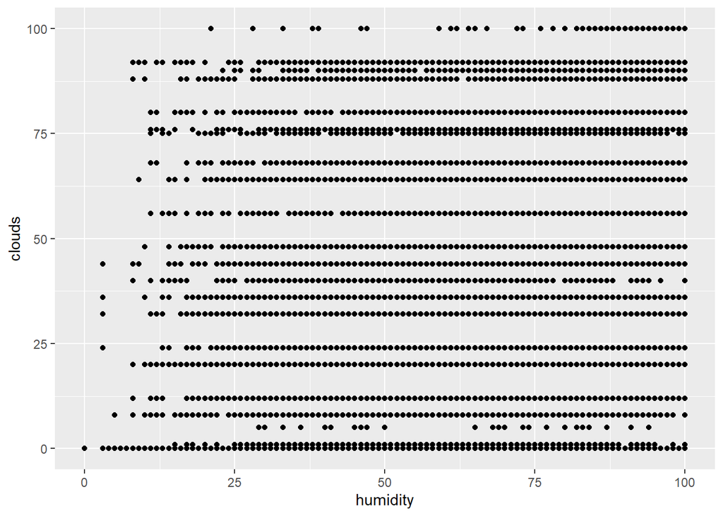

```r
ggplot(data=dat, aes(x=humidity,y=clouds))+geom_point()
```

It can be seen that when humidity is low there tends to be less clouds, when humidity is high there tends to be more clouds.

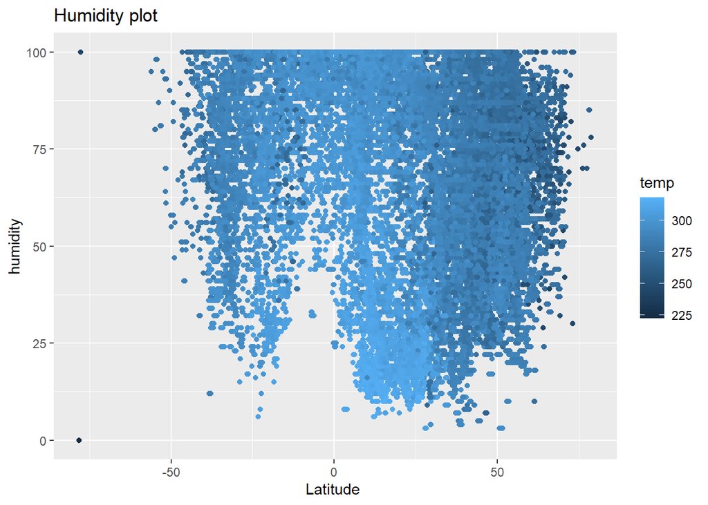

```r
ggplot(data=dat, aes(x=coord$lat,y=humidity,color=temp)) +geom_point() +labs(title="Humidity plot",  x ="Latitude ", y = "humidity")
```

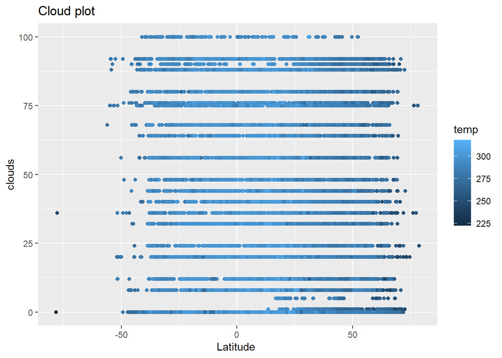

```r
ggplot(data=dat, aes(x=coord$lat,y=clouds,color=temp)) +geom_point() +labs(title="Cloud plot",
x ="Latitude ", y = "clouds")
```

#### Wind

```r
library(viridis)
```

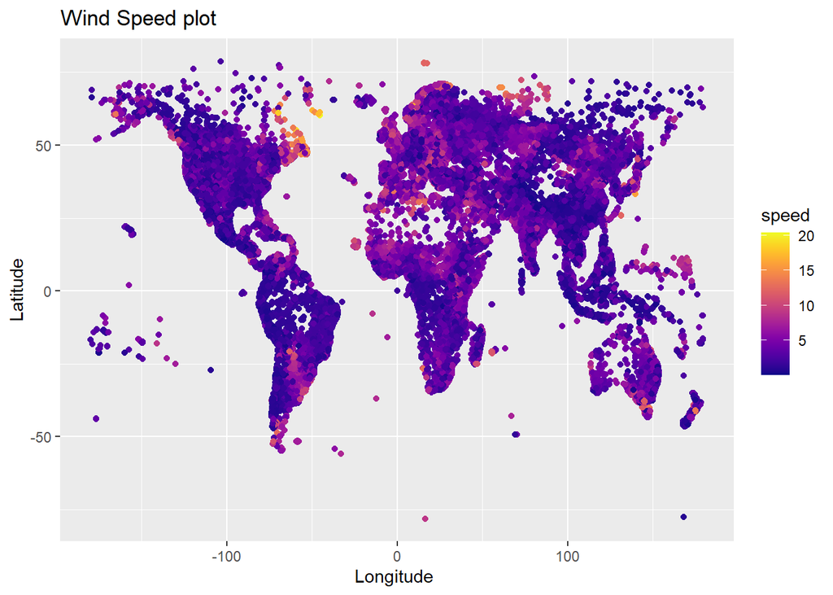

```r
ggplot(data=dat, aes(x=coord$lon,y=coord$lat,color=speed)) +geom_point() +labs(title="Wind Speed plot",  x ="Longitude ", y = "Latitude") + scale_color_viridis(option = "C")
```

It seems that wind speed is not very different for latitudes/longitudes, except for the fact that highest wind speeds mostly occurs at high latitude.